# Intratumoral T-cell and B-cell receptor architecture associates with distinct immune tumor microenvironment features and clinical outcomes of anti-PD-1/L1 immunotherapy

¶ Post-processing predictive modeling results ¶

Aimilia Schina

First created on 16 February 2021. Updated on 20 February 2024

```r
## Clear R-workspace
rm(list=ls(all=TRUE))

## Close all graphic devices
graphics.off()
#####################
### Load packages ###
#####################
library(pacman)

pacman::p_load(extrafont,DT,stringr,dplyr,plyr,tibble,tidyverse,data.table, ggplot2,strex,Hmisc,hrbrthemes,
               ggpubr,mlbench,Amelia,caret, DMwR, DataExplorer,FactoMineR,OutlierDetection,factoextra, parallel,doParallel,scales,precrec,
               RColorBrewer, pander, rlist,
               reconPlots,
               survival,
               survminer, strex, ggplotify,flextable,ggsci, splitstackshape, ggthemes,dichromat)

extrafont::loadfonts(device="win")
windowsFonts(sans="Palatino Linotype")
loadfonts(device="win")
loadfonts(device="postscript")
```

```r
###########################
### Main analysis paths ###
###########################
# Main
scriptsPath <- paste0("scripts/")
scriptsFunctionsPath <- paste0(scriptsPath,"functions/")
projectDataPath <- paste0("data/")
# Input
tcgaInputData <- paste0(projectDataPath,"TCGA/")
antiPDL1publicInputData <- paste0(projectDataPath,"antiPD(L)1_public/")
otherInputData <- paste0(projectDataPath,"other/")
referenceInputData <- paste0(projectDataPath,"reference/")
# Output
projectOutDataPath <- paste0("output/data_files/")
tcgaIntermediateData <- paste0(projectOutDataPath,"TCGA/")
antiPDL1publicIntermediateData <- paste0(projectOutDataPath,"antiPD(L)1_public/")


figuresPath <- paste0("output/figures/")
tablesPath <- paste0("output/tables/")
modelsPath <- paste0("output/models/")

# #Intermediate output
testDataOut <-paste0(modelsPath,"test_data/")
rocCompareOut <-paste0(modelsPath,"roc_compare/")
modelsInterm <- paste0(modelsPath,"models_interm_files/")

# Session/dependencies
sessionInfoPath <- paste0("session_info/")
######################################
## Create intermediate output paths ##
######################################
if (!dir.exists(testDataOut)) {dir.create(testDataOut)}
if (!dir.exists(rocCompareOut)) {dir.create(rocCompareOut)}
if (!dir.exists(modelsInterm)) {dir.create(modelsInterm)}



##################################
### LOAD SOURCE FUNCTIONS FILE ###
##################################
source(paste0(scriptsFunctionsPath,"aPD1_RFE_multivariate_functions.R"), local=T)


#####################
### File suffixes ###
#####################
Rdata.suffix <- ".RData"

# Other script variables
modelTypeA <- "_TCRArichnessIGH.ds"
modelTypeB <- "_noLIU"
modelTypeC <- "_mintcr4bcr10"

#####################
### SCRIPT VARIABLES ###
#####################
run_clean <- FALSE
```

# 1 Loading Sample and Clone data

We are using the data that were TCRa min 4 clones, BCR igh min 10 clones

```r
immdata.TcrBcr.full.red <- loadRData(paste0(antiPDL1publicIntermediateData,"immdata.TcrBcr.full.red",modelTypeA,modelTypeB,modelTypeC,".RData"))
immdata.TcrBcr.full.red$response <- ifelse(immdata.TcrBcr.full.red$response=="CR+PR","CRPR",immdata.TcrBcr.full.red$response)
```

# 2 Looking at available data

First filtering, to keep only CR, PR, PD samples

```r
## FILTER DATA FOR PD, CR, PR (.sub)
immdata.TcrBcr.full.red.sub <- immdata.TcrBcr.full.red %>% dplyr::filter(response %in% c("PD","CRPR")) %>% droplevels()
```

From 695 samples (that include all responses), we drop down to 519, that are CR, PR, PD pre-treatment samples.

Looking at how many of the data have TMB info

```r
datatable(immdata.TcrBcr.full.red.sub %>% dplyr::filter(complete.cases(TMB)) %>% dplyr::select(run_accession,response,tissue) %>% group_by(tissue,response) %>% dplyr::summarise(no_rows=length(response)), extensions = 'Buttons', options = list(
    dom = 'Bfrtip',
    buttons = c('copy', 'excel', 'csv' ),
    scrollX=TRUE,
    pageLength=15
  ),
  caption = 'Number of responders/non-responders in all tissues that have TMB'
)
```

|  | tissue | response | no_rows |
| --- | --- | --- | --- |
| 1 | bladder | CRPR | 71 |
| 2 | bladder | PD | 144 |
| 3 | melanoma | CRPR | 58 |
| 4 | melanoma | PD | 69 |
| 5 | RCC | CRPR | 12 |
| 6 | RCC | PD | 19 |

From 519 CRPR, PD samples, we drop down to 373, that are CR, PR, PD pre-treatment samples. The only tissues we can actually use for the model are melanoma and bladder, that have more than 100 samples.

Prepare other variables and dataframes necessary for the analysis.

```r
## EXTRACT RESPONSE, NOMINAL, MEASURE VARIABLES FROM DATA
response.var <- "response"
nominal.vars <- c("dataset","tissue","gender")

measure.vars <-colnames(immdata.TcrBcr.full.red.sub)[c(2:10,12,32:43)]
measure.vars <- measure.vars[c(6,22,1:3,20,21,4:5,10,7:9,11:19)]



## CHECK INFINITE LOG TMB VALUES
immdata.TcrBcr.full.red.sub[which(is.infinite(immdata.TcrBcr.full.red.sub$logTMB)),]
```

```
##  [1] run_accession      TuTACK_sigscore    TIS_sigscore       PDL1               CD8A               CD8B               TCRArichness.ds
##  [8] StromalScore       ImmuneScore        ESTIMATEScore      title              age                gender             disease_status
## [15] biopsy_site        primary_tumor      treatment          prior_treatment    response           OS.time            OS
## [22] PFS.time           PFS                pre_on_treatment   total_muts         nonsyn_muts        clonal_muts        subclonal_muts
## [29] TMB                tissue             dataset            Bcells             CD8cells           CD4cells           Tregs
## [36] NKcells            DCcells            Monocytes          Granulocytes       Macrophages        TumorPurity        logTMB
## [43] BCR.IGHrichness.ds
## <0 rows> (or 0-length row.names)
```

```r
## Extract tissues in data so far
tissues <- unique(immdata.TcrBcr.full.red.sub$tissue)

# Keep samples with TMB (.tmb)
immdata.TcrBcr.full.red.sub.tmb <- immdata.TcrBcr.full.red.sub %>% dplyr::filter(complete.cases(logTMB)) %>% droplevels()#;nrow(immdata.TcrBcr.full.red.sub.tmb)
# ONLY MELANOMA, WITH TMB (.tmb.MEL)
immdata.TcrBcr.full.red.sub.tmb.MEL <- immdata.TcrBcr.full.red.sub.tmb %>% dplyr::filter(tissue=="melanoma") %>% droplevels()#;nrow(immdata.TcrBcr.full.red.sub.tmb.MEL)
## ALL MELANOMA AND BLADDER, WITH TMB (.tmb.ALL)
immdata.TcrBcr.full.red.sub.tmb.ALL <- immdata.TcrBcr.full.red.sub.tmb %>% dplyr::filter(tissue %in% c("melanoma","bladder")) %>% droplevels()#;nrow(immdata.TcrBcr.full.red.sub.tmb.ALL)
# ALL DATA, MELANOMA AND BLADDER, BUT LEAVE MISSING TMB (.ALL)
immdata.TcrBcr.full.red.sub.ALL <- immdata.TcrBcr.full.red.sub %>% dplyr::filter(tissue %in% c("melanoma","bladder")) %>% droplevels()#;nrow(immdata.TcrBcr.full.red.sub.ALL)

# Which are the covariates I am considering
covariatesIn <- measure.vars[c(1:2,4:7,14:16)]
responseVar <- "response"

immdata.TcrBcr.full.red <-immdata.TcrBcr.full.red.sub  %>% droplevels()

immdata.TcrBcr.full.red.sub <- immdata.TcrBcr.full.red.sub %>% droplevels()

## INSTEAD OF FILTERING FOR NO MISSING TMB, I DO THAT FOR ALL COVARIATES OF INTEREST
# Remove rows that have outliers/missing values since I get errors with Knn imputation
immdata.TcrBcr.full.red.sub.ALL.filt <- immdata.TcrBcr.full.red.sub.ALL %>% filter_at(vars(covariatesIn), all_vars(complete.cases(.))) %>% droplevels()
# DOING THE SAME FOR THE ORIGINAL DATA - USE THIS WHEN TESTING
# these data include other tissues apart from melanoma and bladder
immdata.TcrBcr.full.red.sub.filt <- immdata.TcrBcr.full.red.sub %>% filter_at(vars(covariatesIn), all_vars(complete.cases(.))) %>% droplevels()

# FINAL DATA FOR MODELLING
# Remove the Liu dataset for the model testing
immdata.TcrBcr.BLAD.MEL.ready <-immdata.TcrBcr.full.red.sub.ALL.filt %>% dplyr::filter(dataset %notin% c("Liu") ) %>% droplevels() # All melanoma & bladder, PD, CR, PR, complete data
immdata.TcrBcr.ALL.ready <- immdata.TcrBcr.full.red.sub.filt %>% dplyr::filter(dataset %notin% c("Liu") ) %>% droplevels() # All tissues, PD, CR, PR, complete data

## For gastric
immdata.TcrBcr.full.red.sub.filt.gastric <- immdata.TcrBcr.full.red.sub %>% dplyr::filter(tissue %in% c("gastric") ) %>%
                                            filter_at(vars(covariatesIn[-6]), all_vars(complete.cases(.))) %>% droplevels()
```

# 3 Preprocessing

The data need to be preprocessed, centered, scaled.

```r
DF <- immdata.TcrBcr.full.red.sub.filt
# KEEP ALL DATA, dont deal with NA
DF.complete <- DF %>% column_to_rownames(var="run_accession") %>% dplyr::select(c(responseVar,covariatesIn)) %>% dplyr::filter(complete.cases(.)) %>% droplevels()
DF.complete[[responseVar]] <- as.factor(DF.complete[[responseVar]])
levels(DF.complete[[responseVar]]) <- c("CRPR","PD")
DF.complete <-DF.complete[,c(responseVar,covariatesIn)]


## Selecet train data
set.seed(3456)
training.samples <- DF.complete$response %>%
  createDataPartition(p = 0.8, list = FALSE)
train.data  <- DF.complete[training.samples, ]
test.data <- DF.complete[-training.samples, ]

x <- DF.complete %>% dplyr::select(-response)
y <- DF.complete$response
x_test <-x[-training.samples, ]
y_test <-y[-training.samples]

# tRAIN
pP <- preProcess(train.data, method = c('knnImpute', 'center', 'scale'))
train.pP <- predict(pP, train.data)
## FULL DATA
pP.full <- preProcess(DF %>% dplyr::select(c(responseVar,covariatesIn)) , method = c('knnImpute', 'center', 'scale'))
DF.pP <- predict(pP.full, DF %>% column_to_rownames(var="run_accession") %>% dplyr::select(c(responseVar,covariatesIn)))
```

## 3.1 Histograms

TRAIN DATA

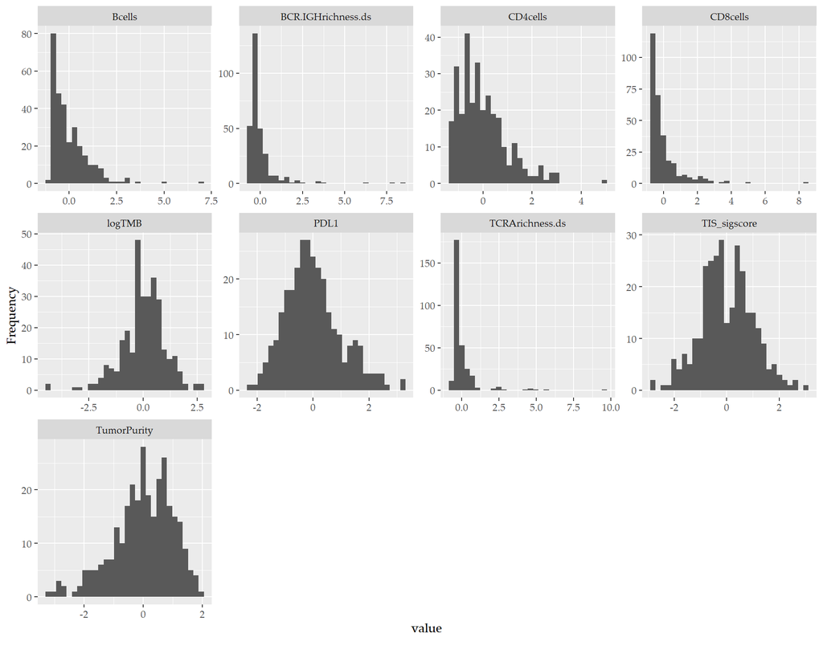

```r
plot_histogram(train.pP)
```

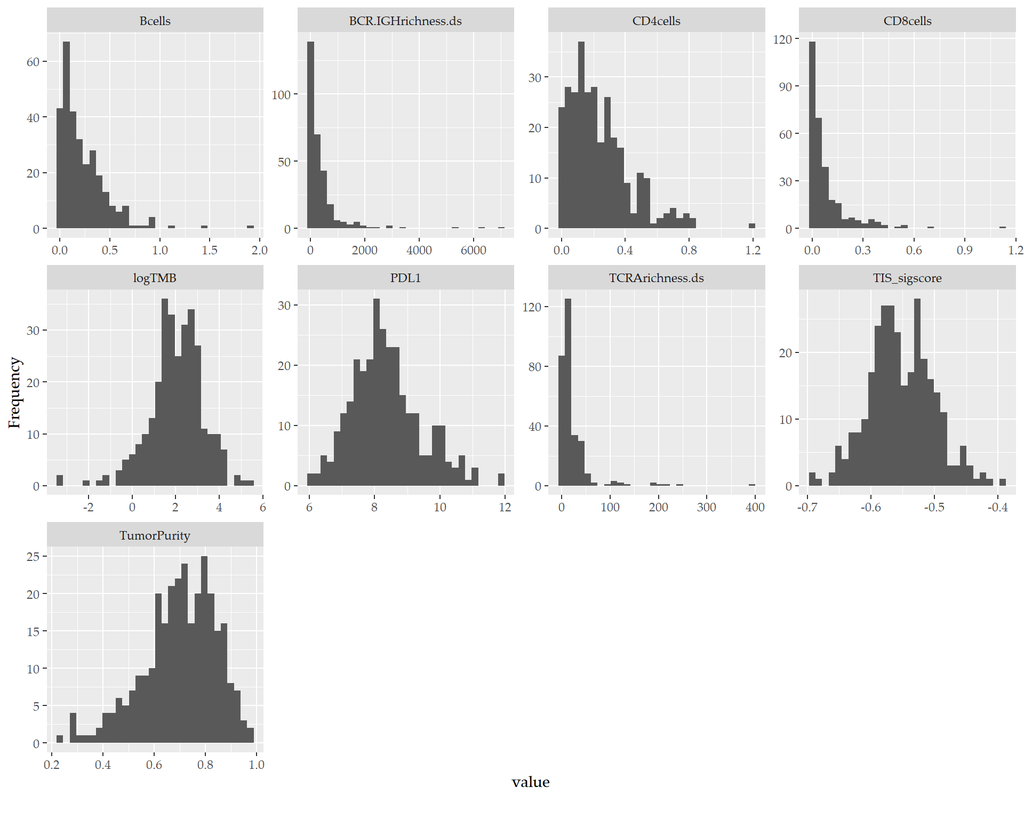

```r
plot_histogram(train.data)
```

# 4 PCA

## 4.1 With preprocessing

Data centered and scaled and imputed

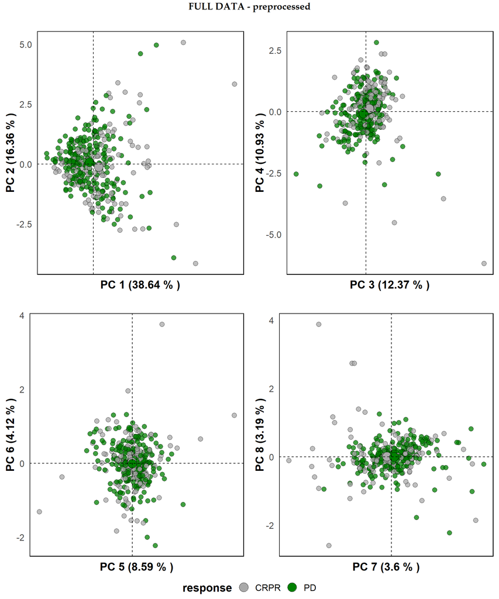

```r
data_full <- DF.pP %>% dplyr::select(c(responseVar,covariatesIn))
pca_axis <-list(c(1,2),c(3,4),c(5,6),c(7,8))#,c(9,10),c(11,12)
# pca_axis <-list(c(1,2))

pca_plots<-lapply(1:length(pca_axis), function(x) pca_biPlot(data_full,responseVar,NULL,covariatesIn,NULL,as.factor(data_full$response),"response",axes=pca_axis[[x]]))

# n<-round(length(pca_plots)/2);
n<-length(pca_plots);

graphCols <-ceiling(n/floor(sqrt(n)));
graphRows<-floor(sqrt(n))

pca_plots.all<-ggpubr::ggarrange(plotlist = pca_plots, nrow = graphRows,ncol = graphCols, common.legend = TRUE, legend = "bottom")

annotate_figure(pca_plots.all,
               top = text_grob("FULL DATA - preprocessed", color = "black", face = "bold", size = 14))
```

## 4.2 Without preprocessing

Data not scaled not centered, not imputed, so filtering for complete cases

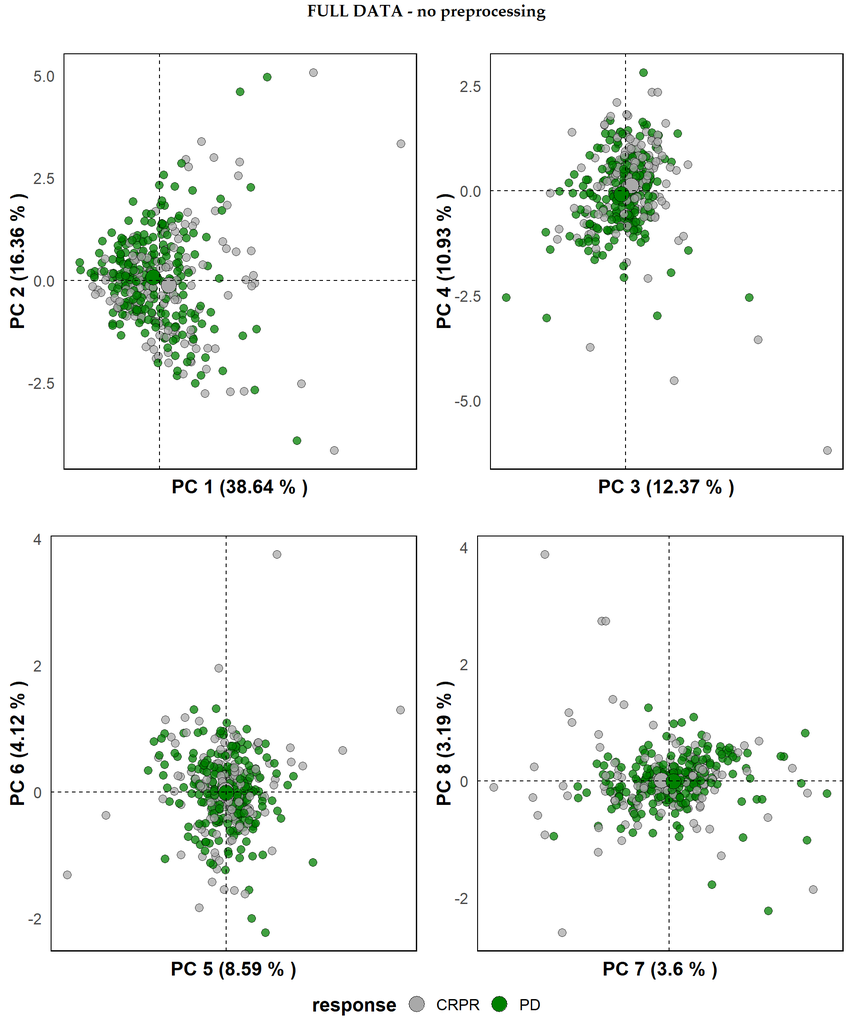

```r
data_full <- DF %>% dplyr::select(c(responseVar,covariatesIn)) %>% dplyr::filter(complete.cases(.)) %>% droplevels()
pca_axis <-list(c(1,2),c(3,4),c(5,6),c(7,8))#,c(9,10),c(11,12)
# pca_axis <-list(c(1,2))

pca_plots<-lapply(1:length(pca_axis), function(x) pca_biPlot(data_full,responseVar,NULL,covariatesIn,NULL,as.factor(data_full$response),"response",axes=pca_axis[[x]]))

# n<-round(length(pca_plots)/2);
n<-length(pca_plots);

graphCols <-ceiling(n/floor(sqrt(n)));
graphRows<-floor(sqrt(n))

pca_plots.all<-ggpubr::ggarrange(plotlist = pca_plots, nrow = graphRows,ncol = graphCols, common.legend = TRUE, legend = "bottom")

annotate_figure(pca_plots.all,
               top = text_grob("FULL DATA - no preprocessing", color = "black", face = "bold", size = 14))
```

# 5 Model building

We are subsetting to all the data that have ALL the information, i.e. removing missing data - imputation is left out at this point.

$$Response[CRPR/PD] = TCR{\ }alpha{\ }richness + BCR{\ }igh{\ }richness +
TIS{\_}score+ Tumor{\ }purity + CD8{\ }T-cells{\ }infiltration + CD4{\
}T-cells{\ }infiltration + B{\ }-cells{\ }infiltration + PDL-1{\
}expression + logTMB + gender(?)$$
From this full model, we want to perform feature selection (swith recursive feature elimination) to end up with the simplest solution. TCRalpha richness is necessary to be in the model.

# 6 SCHEME 1

```r
table(immdata.TcrBcr.ALL.ready$tissue)
```

```
##
##  bladder melanoma      RCC
##      215       52       31
```

SO FOR TRAINING THE DATA WE HAVE THIS:

**TOTAL available data**

```r
nrow(immdata.TcrBcr.BLAD.MEL.ready)
```

```
## [1] 267
```

**Table of available data per dataset**

```r
table(immdata.TcrBcr.BLAD.MEL.ready$dataset)
```

```
##
##   Hugo   Mari Powles   Riaz
##     28    148     67     24
```

**Table of available data per tissue**

```r
table(immdata.TcrBcr.BLAD.MEL.ready$tissue)
```

```
##
##  bladder melanoma
##      215       52
```

## 6.1 Multivariate Logistic Regression

### 6.1.1 Feature Selection

#### 6.1.1.1 Recursive feature elimination (RFE)

Initial predictors in:

1. TCR alpha Richness
2. BCR-IGH Richness
3. Tumor Purity( removing Stromal, Immune score and Estimate score since they are highly correlated, and I think that might confound the results)
4. CD4 T cell infiltration (cibersort)
5. CD8 T cell infiltration (cibersort) - removed CD8A, CD8B gene expression, >0.8 correlation with CD8 T cell infiltration
6. B cells
7. logTMB
8. PD-L1
9. GEP signature score
10. gender (??)

Collecting the results from all the different models, and optimization results, in order to select model and optimal parameters that will be applied to the rest of the solo models.

We tried the following models along with RFE:

1. Random Forest
2. Linear Logistic Regression
3. Naive Bayes
4. Support Vector Machine Radial
5. Support vector Machine Linear
6. K-Nearest Neighbours

Repeated K-fold CV was applied for the RFE and training of the machine learning model with K-fold CV. Centering and scaling preprocessing was applied in each of the resamples, in order to avoid data leakage in the tuning of the parameters and selection of the final model.

```r
#######################
## RUN SINGLE MODELS ##
#######################
rfe_rf <- loadRData(paste0(modelsPath,"optimizationParamsModels","_RFE","_RF",modelTypeA,modelTypeB, modelTypeC,Rdata.suffix))
# rfe_rf[which(rfe_rf$ROC==max(rfe_rf$ROC)),]
# hist(rfe_rf$ROC)
# rfe_rf[order(rfe_rf$ROC, decreasing = TRUE),] %>% head()
rfe_rf.opt <-rfe_rf[which(rfe_rf$ROC==max(rfe_rf$ROC)),]
# #
# #
rfe_lr <- loadRData(paste0(modelsPath,"optimizationParamsModels","_RFE","_LR",modelTypeA,modelTypeB, modelTypeC,Rdata.suffix))
# rfe_lr[which(rfe_lr$ROC==max(rfe_lr$ROC)),]
# hist(rfe_lr$ROC)
# rfe_lr[order(rfe_lr$ROC, decreasing = TRUE),] %>% head()
rfe_lr.opt <-rfe_lr[which(rfe_lr$ROC==max(rfe_lr$ROC)),]
# #
# #
# #
rfe_nb <- loadRData(paste0(modelsPath,"optimizationParamsModels","_RFE","_NB",modelTypeA,modelTypeB, modelTypeC,Rdata.suffix))
# rfe_nb[which(rfe_nb$ROC==max(rfe_nb$ROC)),]
# hist(rfe_nb$ROC)
# rfe_nb[order(rfe_nb$ROC, decreasing = TRUE),] %>% head()
rfe_nb.opt <-rfe_nb[which(rfe_nb$ROC==max(rfe_nb$ROC)),]

# rfe_nb <- loadRData(paste0(projectRDataPathC,"optimizationParamsModels","_RFE","_NB",modelTypeA,modelTypeB, modelTypeC,Rdata.suffix))
# rfe_nb[which(rfe_nb$ROC==max(rfe_nb$ROC)),]
# hist(rfe_nb$ROC)
# rfe_nb[order(rfe_nb$ROC, decreasing = TRUE),] %>% head()
# rfe_nb.opt <-rfe_nb[which(rfe_nb$ROC==max(rfe_nb$ROC)),]
# #
# #
rfe_svmr <- loadRData(paste0(modelsPath,"optimizationParamsModels","_RFE","_SVMr",modelTypeA,modelTypeB, modelTypeC,Rdata.suffix))
# rfe_svmr[which(rfe_svmr$ROC==max(rfe_svmr$ROC)),]
# hist(rfe_svmr$ROC)
# rfe_svmr[order(rfe_svmr$ROC, decreasing = TRUE),] %>% head()
rfe_svmr.opt <-rfe_svmr[which(rfe_svmr$ROC==max(rfe_svmr$ROC)),]
# #
rfe_svml <- loadRData(paste0(modelsPath,"optimizationParamsModels","_RFE","_SVMl",modelTypeA,modelTypeB, modelTypeC,Rdata.suffix))
# rfe_svml[which(rfe_svml$ROC==max(rfe_svml$ROC)),]
# hist(rfe_svml$ROC)
# rfe_svml[order(rfe_svml$ROC, decreasing = TRUE),] %>% head()
rfe_svml.opt <-rfe_svml[which(rfe_svml$ROC==max(rfe_svml$ROC)),]
# #
rfe_knn <- loadRData(paste0(modelsPath,"optimizationParamsModels","_RFE","_KNN",modelTypeA,modelTypeB, modelTypeC,Rdata.suffix))
# rfe_knn[which(rfe_knn$ROC==max(rfe_knn$ROC)),]
# hist(rfe_knn$ROC)
# rfe_knn[order(rfe_knn$ROC, decreasing = TRUE),] %>% head()
rfe_knn.opt <-rfe_knn[which(rfe_knn$ROC==max(rfe_knn$ROC)),]
# #
# #
rfe.models.opt <- list(`Random Forest` = rfe_rf.opt,
                       `Linear Logistic Regression` = rfe_lr.opt,
                       `Naive Bayes` = rfe_nb.opt,
                       `SVM Radial` = rfe_svmr.opt,
                       `SVM Linear` = rfe_svml.opt,
                       `K-Nearest Neighbours` = rfe_knn.opt)

rfe.models.opt.DF <-bind_rows(rfe.models.opt, .id = "model")

# Find optimal parameters and model
# rfe.models.opt.DF2 <- rbind(rfe.models.opt.DF,rfe.models.opt.DF)
rfe.models.opt.final <-rfe.models.opt.DF %>% dplyr::filter(ROC == max(ROC)) %>% slice(1)
# rfe.models.opt.DF.m <- rfe.models.opt.DF %>% dplyr::select(model, ROC, PPV, NPV, split, kfolds, subsampling) %>% melt(id.vars = c("model","split", "kfolds", "subsampling"))
#
# rfe.models.opt.DF.m$params <- paste0("Split = ",rfe.models.opt.DF.m$split, ", K-fold = ",rfe.models.opt.DF.m$kfolds, " , Sampling = ",rfe.models.opt.DF.m$subsampling)
#
# # ggplot(rfe.models.opt.DF %>% dplyr::select(model, ROC, PPV, NPV) %>% melt(), aes(fill=variable, y=value, x=model)) +
# #     geom_bar(position="dodge", stat="identity")
# rfe.models.opt.DF.m$model <- factor(rfe.models.opt.DF.m$model,levels = unique(rfe.models.opt.DF.m$model))
optimal.model <- rfe.models.opt.final$model
print(paste0(">>>>Model giving best results is: ", optimal.model,"<<<<<<<"))
```

[1] “>>>>Model giving best results is: Naive Bayes<<<<<<<”

```r
kFold.opt = rfe.models.opt.final$kfolds
Sampling.opt =rfe.models.opt.final$subsampling
split.opt =rfe.models.opt.final$split
optList = list(kfold = kFold.opt,
               sampling=Sampling.opt,
               split = split.opt)

rfe.models.opt.DF.m <- rfe.models.opt.DF %>% dplyr::select(model, ROC, PPV, NPV, split, kfolds, subsampling) %>% melt(id.vars = c("model","split", "kfolds", "subsampling"))

rfe.models.opt.DF.m$params <- paste0("Split = ",rfe.models.opt.DF.m$split, ", K-fold = ",rfe.models.opt.DF.m$kfolds, " , Sampling = ",rfe.models.opt.DF.m$subsampling)

# ggplot(rfe.models.opt.DF %>% dplyr::select(model, ROC, PPV, NPV) %>% melt(), aes(fill=variable, y=value, x=model)) +
#     geom_bar(position="dodge", stat="identity")
rfe.models.opt.DF.m$model <- factor(rfe.models.opt.DF.m$model,levels = unique(rfe.models.opt.DF.m$model))
```

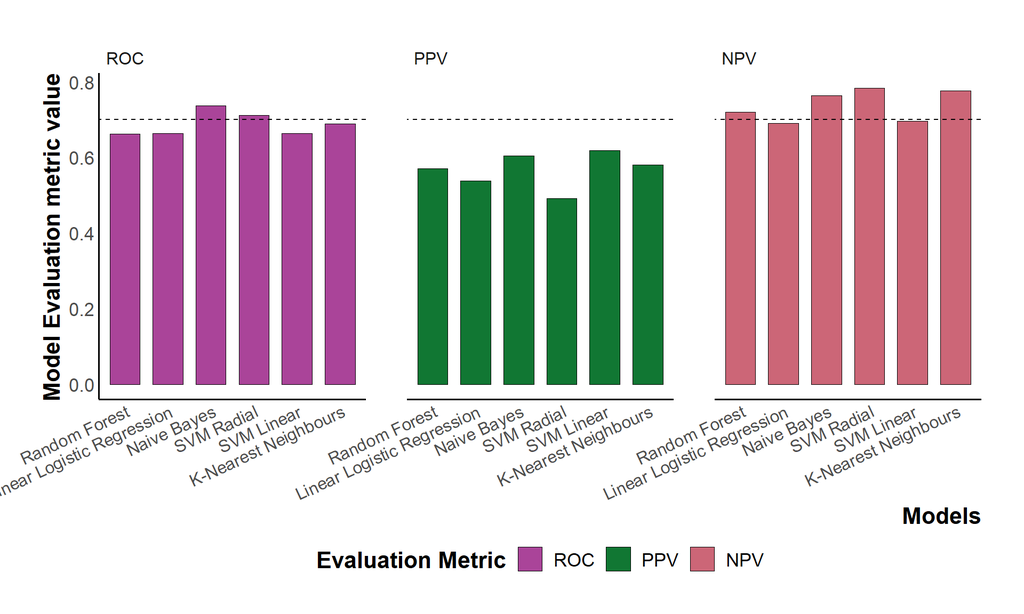

```r
simpleBarchart(rfe.models.opt.DF.m, "model", "value", "variable", "variable", "Models", "Model Evaluation metric value",123,FALSE,legendTitle="Evaluation Metric",ratioLine = TRUE,type="reps")
```

```r
rfeModelsEval.Bar <- simpleBarchart(rfe.models.opt.DF.m, "model", "value", "variable", "variable", "Models", "Model Evaluation metric value",123,FALSE,legendTitle="Evaluation Metric",ratioLine = TRUE,type="reps")
```

We will extract this model and it’s optimal parameters, optimal split, sampling and k-folds for the CV, to use for all the rest (and previous solo) models.

```r
save(optList,
     file=paste0(modelsPath,"paramOptim/","model_FINALoptParams",modelTypeA,modelTypeB, modelTypeC,Rdata.suffix))
```

**OPTIMAL PARAMETERS FOR RUNNING ALL MODELS**

- K-fold: 10
- Sampling: smote
- Train split: 0.7

Load models with optimal parameters

```r
model_rf <- loadRData(paste0(modelsPath,"paramOptim/","rf_optParams",modelTypeA,modelTypeB,modelTypeC,Rdata.suffix))
model_lr <- loadRData(paste0(modelsPath,"paramOptim/","lr_optParams",modelTypeA,modelTypeB,modelTypeC,Rdata.suffix))
model_nb <- loadRData(paste0(modelsPath,"paramOptim/","nb_optParams",modelTypeA,modelTypeB,modelTypeC,Rdata.suffix))
model_svmr <- loadRData(paste0(modelsPath,"paramOptim/","svmr_optParams",modelTypeA,modelTypeB,modelTypeC,Rdata.suffix))
model_svml <- loadRData(paste0(modelsPath,"paramOptim/","svml_optParams",modelTypeA,modelTypeB,modelTypeC,Rdata.suffix))
model_knn <- loadRData(paste0(modelsPath,"paramOptim/","knn_optParams",modelTypeA,modelTypeB,modelTypeC,Rdata.suffix))
```

```r
train.rfe <- list(rfModel = model_rf$model,
                  lrModel = model_lr$model,
                  nbModel = model_nb$model,
                  svmRadModel = model_svmr$model,
                  svmLinModel = model_svml$model,
                  knnModel = model_knn$model
                  )
```

```r
ClassLevels = c("CRPR","PD")
sigs <- c("Random Forest", "Linear Regression","Naive Bayes","SVM Radial","SVM Linear","K-Nearest Neighbors")
sigs_axisNames<- c("Random Forest", "Linear Regression","Naive Bayes","SVM Radial","SVM Linear","K-Nearest Neighbors")
sigs_titleNames<- c("Random Forest", "Linear Regression","Naive Bayes","SVM Radial","SVM Linear","K-Nearest Neighbors")
names(train.rfe) <- c(paste0('RF: R ~ ',paste(predictors(train.rfe[[1]]), collapse = " + ")),
                     paste0('LR: R ~ ',paste(predictors(train.rfe[[2]]), collapse = " + ")),
                     paste0('NB: R ~ ',paste(predictors(train.rfe[[3]]), collapse = " + ")),
                     paste0('SVM-Radial: R ~ ',paste(predictors(train.rfe[[4]]), collapse = " + ")),
                     paste0('SVM-Linear: R ~ ',paste(predictors(train.rfe[[5]]), collapse = " + ")),
                     paste0('KNN: R ~ ',paste(predictors(train.rfe[[6]]), collapse = " + "))
                     )
```

```r
sapply(1:length(train.rfe), function(x) paste(predictors(train.rfe[[x]]), collapse = " + "))
```

```
## [1] "logTMB + TumorPurity + TIS_sigscore + PDL1 + Bcells + CD4cells + TCRArichness.ds"
## [2] "TumorPurity + logTMB + BCR.IGHrichness.ds + PDL1 + Bcells + TCRArichness.ds + CD8cells + TIS_sigscore"
## [3] "logTMB + PDL1 + TCRArichness.ds + TIS_sigscore + CD8cells + BCR.IGHrichness.ds + TumorPurity + Bcells + CD4cells"
## [4] "logTMB + PDL1 + TCRArichness.ds"
## [5] "logTMB + PDL1 + TCRArichness.ds + TIS_sigscore + CD8cells + BCR.IGHrichness.ds + TumorPurity + Bcells + CD4cells"
## [6] "logTMB + PDL1 + TCRArichness.ds + TIS_sigscore + CD8cells + BCR.IGHrichness.ds + TumorPurity + Bcells + CD4cells"
```

#### 6.1.1.2 Variable Importance

```r
vp <-sapply(1:length(train.rfe), function(x) varimpPlot(train.rfe[[x]],sigs[x]))
```

#### 6.1.1.3 Random Forest

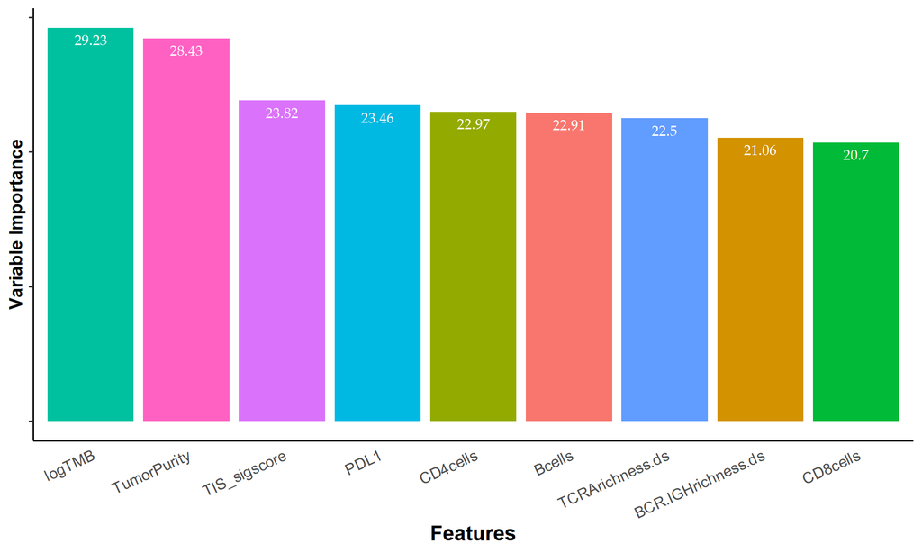

#### 6.1.1.4 Linear Regression

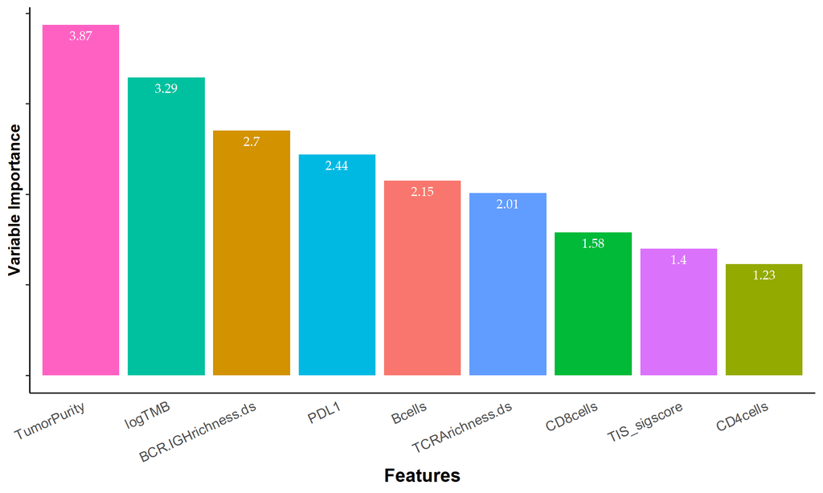

#### 6.1.1.6 SVM Radial

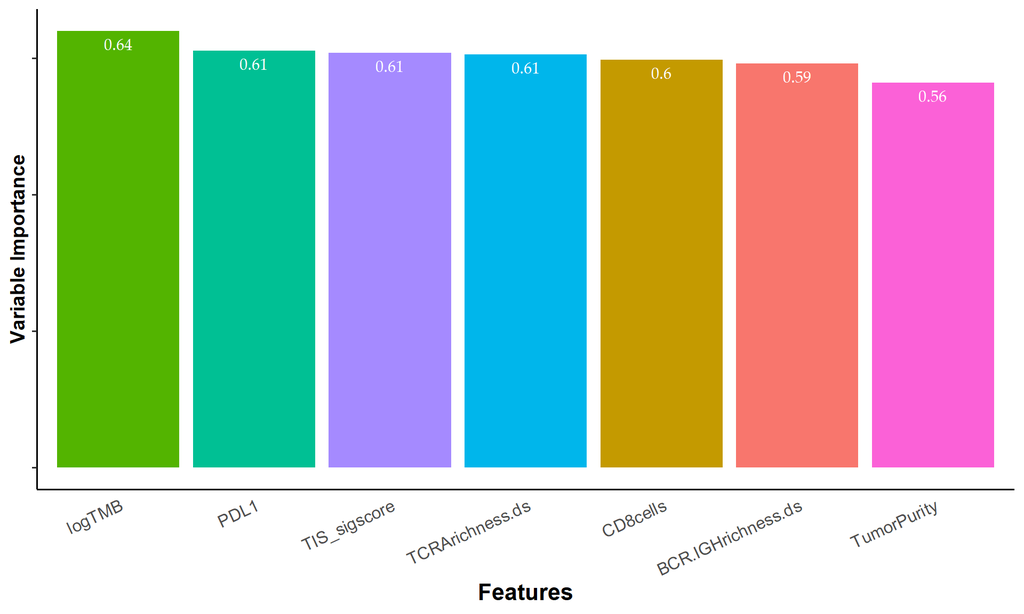

```r
### Repeated CV ROC

# only if repeats saved
repCVrocp <-sapply(1:length(train.rfe), function(x) repCVrocPlot(train.rfe[[x]],sigs[x]))
```

## 6.2 RECURSIVE FEATURE ELIMINATION MODELS

Extract and save test data.

```r
######################

testDF.nb <-checkLogRegModelTEST(DF = immdata.TcrBcr.ALL.ready,models.all = model_nb,model.name = "logTMB",
                     obsColumn = "run_accession",
                     filtered = TRUE,scaled=TRUE,rfeE=TRUE)
```

```
## [1] ">>> Extract scaling factor <<<"
## [1] "There might be left over test data in original data"
## [1] "==Checking if there is a leak of train in test data"
## [1] "===TOTAL TEST DATA=="
##
##  bladder melanoma      RCC
##       59       20       31
##
##        Hugo Immotion150        Mari        Miao      Powles        Riaz
##          12          21          43          10          16           8
```

```r
# Compare with the previous test data, to be sure they include same samples
testDF <- list(testDF.nb)
# setdiff(testDF[[1]]$run_accession,testDF.nb$run_accession)
# setdiff(testDF.nb$run_accession,testDF[[1]]$run_accession)

save(testDF,file=paste0(testDataOut,"testDF",modelTypeA,modelTypeB, modelTypeC,".RData"))

## GASTRIC
testDF.gastric <-checkLogRegModelTEST(DF = immdata.TcrBcr.full.red.sub.filt.gastric,models.all = model_nb,model.name = "PDL1",
                     obsColumn = "run_accession",
                     filtered = TRUE,scaled=TRUE,rfeE=TRUE)
```

```
## [1] ">>> Extract scaling factor <<<"
## [1] "There might be left over test data in original data"
## [1] "==Checking if there is a leak of train in test data"
## [1] "===TOTAL TEST DATA=="
##
## gastric
##      29
##
## Kim
##  29
```

```r
save(testDF.gastric,file=paste0(testDataOut,"testDF.gastric",modelTypeA,modelTypeB, modelTypeC,".RData"))

data.testX <- as.data.frame(testDF[[1]][,which(colnames(testDF[[1]]) %in% covariatesIn)])

test.ALL <- rbind(testDF[[1]],immdata.TcrBcr.full.red.sub.ALL.filt %>% dplyr::filter(dataset %in% c("Liu") ) %>% droplevels())
data.testX.ALL <- as.data.frame(test.ALL[,which(colnames(test.ALL) %in% covariatesIn)])
```

## 6.3 LOGISTIC REGRESSION: UNI/BIVARIATE MODELS

### 6.3.1 Training models

Loading optimal parameters for running all the models (found by selecting best RFE model)

```r
optList <-loadRData(paste0(modelsPath,"paramOptim/","model_FINALoptParams",modelTypeA,modelTypeB, modelTypeC,Rdata.suffix))
```

```r
train.modelsSolo <- loadRData(paste0(modelsInterm,"models_solo",modelTypeA,modelTypeB, modelTypeC,Rdata.suffix))

res.logTMB <-trainRUN(immdata.TcrBcr.BLAD.MEL.ready,split = optList$split,ClassLevels = c("CRPR","PD"),PositiveClass = "CRPR",LevelIndex = 1,
         seed.partition = 3456,seed.model = 5627,setCVseeds=NULL,
         dummy=FALSE,dummyVars=c("tissue"),categVars=c("tissue","dataset"),obsColumn = "run_accession",responseVar = "response",
         REPEATS = 30,KFOLDS = optList$kfold,
         metricOpt = "F",subsampMethod=optList$sampling,inoutSub="in",
         paste("logTMB",collapse = " + "),controlDum=FALSE,model.name = "logTMB",mainFeats = c("logTMB"),
         removeOutliers=FALSE,quantileClass1=.95,quantileClass2=.95,selectOutlierMethod= "meanDist",
         stratify=FALSE,fullResults=TRUE,
         positiveCoefs=FALSE, filter=TRUE,filterVar="dataset",filterSelected=c("Powles","Gide","Mari","Rod","Hugo","Riaz"),
         CorrRemove=FALSE,corrThres=NULL,selectedScale=TRUE)
```

```
## [1] "==INITIAL INPUT DATA=="
## [1] "======================="
##
## CRPR   PD
##   95  172
##
##  bladder melanoma
##      215       52
## [1] "======================="
## [1] "==MODEL/PIPELINE PARAMETERS=="
## [1] "=============================="
## [1] "Outlier filtering: FALSE"
## [1] "Dataset Filtering: TRUE"
## [1] "Datasets selected: Powles" "Datasets selected: Gide"   "Datasets selected: Mari"   "Datasets selected: Rod"    "Datasets selected: Hugo"
## [6] "Datasets selected: Riaz"
```

[output cut: 91 more lines]

In the initial simple splitting of data based on response I noticed an unbalanced splitting of tissues, so a lot moe bladder data where included in the train data, and eventually a lot more melanoma data where included in the test data. I will try to balanced this.

Resampling results from training solo predictor models on train data:

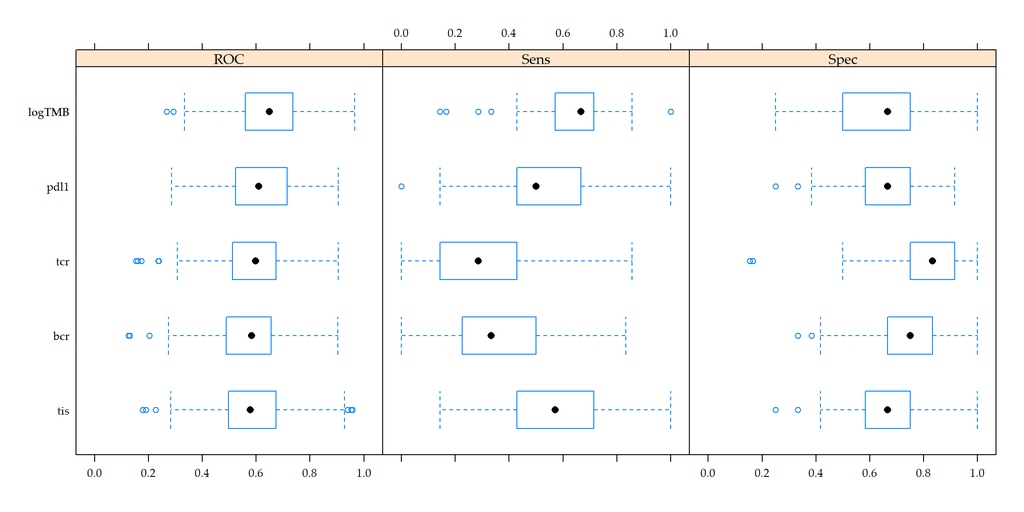

```r
bwplot(resamples(train.modelsSolo))
```

Automatically test the models on test data, automatic calculation of leftover test data, selection of test data etc. .

### 6.3.2 Test data for all models

```r
######################

testDF.tcra <-checkLogRegModelTEST(DF = immdata.TcrBcr.ALL.ready,models.all = res.logTMB,model.name = "logTMB",
                     obsColumn = "run_accession",
                     filtered = TRUE,scaled=TRUE)
```

```
## [1] ">>> Extract scaling factor <<<"
## [1] "There might be left over test data in original data"
## [1] "==Checking if there is a leak of train in test data"
## [1] "===TOTAL TEST DATA=="
##
##  bladder melanoma      RCC
##       59       20       31
##
##        Hugo Immotion150        Mari        Miao      Powles        Riaz
##          12          21          43          10          16           8
```

```r
testDF.logTMB <-checkLogRegModelTEST(DF = immdata.TcrBcr.ALL.ready,models.all = res.logTMB,model.name = "logTMB",
                     obsColumn = "run_accession",
                     filtered = TRUE,scaled=TRUE)
```

```
## [1] ">>> Extract scaling factor <<<"
## [1] "There might be left over test data in original data"
## [1] "==Checking if there is a leak of train in test data"
## [1] "===TOTAL TEST DATA=="
##
##  bladder melanoma      RCC
##       59       20       31
##
##        Hugo Immotion150        Mari        Miao      Powles        Riaz
##          12          21          43          10          16           8
```

```r
testDF.pdl1 <-checkLogRegModelTEST(DF = immdata.TcrBcr.ALL.ready,models.all = res.logTMB,model.name = "logTMB",
                     obsColumn = "run_accession",
                     filtered = TRUE,scaled=TRUE)
```

```
## [1] ">>> Extract scaling factor <<<"
## [1] "There might be left over test data in original data"
## [1] "==Checking if there is a leak of train in test data"
## [1] "===TOTAL TEST DATA=="
##
##  bladder melanoma      RCC
##       59       20       31
##
##        Hugo Immotion150        Mari        Miao      Powles        Riaz
##          12          21          43          10          16           8
```

```r
testDF.bcr <-checkLogRegModelTEST(DF = immdata.TcrBcr.ALL.ready,models.all = res.logTMB,model.name = "logTMB",
                     obsColumn = "run_accession",
                     filtered = TRUE,scaled=TRUE)
```

```
## [1] ">>> Extract scaling factor <<<"
## [1] "There might be left over test data in original data"
## [1] "==Checking if there is a leak of train in test data"
## [1] "===TOTAL TEST DATA=="
##
##  bladder melanoma      RCC
##       59       20       31
##
##        Hugo Immotion150        Mari        Miao      Powles        Riaz
##          12          21          43          10          16           8
```

```r
testDF.tis <-checkLogRegModelTEST(DF = immdata.TcrBcr.ALL.ready,models.all = res.logTMB,model.name = "logTMB",
                     obsColumn = "run_accession",
                     filtered = TRUE,scaled=TRUE)
```

```
## [1] ">>> Extract scaling factor <<<"
## [1] "There might be left over test data in original data"
## [1] "==Checking if there is a leak of train in test data"
## [1] "===TOTAL TEST DATA=="
##
##  bladder melanoma      RCC
##       59       20       31
##
##        Hugo Immotion150        Mari        Miao      Powles        Riaz
##          12          21          43          10          16           8
```

```r
testDF <- list(testDF.tcra,
               testDF.bcr,
               testDF.logTMB,
               testDF.pdl1,
               testDF.tis
               )
```

## 6.4 RFE-NB vs Univariate & Bi-/Tri-variate LOGREG MODELS

Moving forward with the RFE - Naive Bayes model, since it seems to be the best performing model.

```r
## SELECTING MODELS
# Loading models of manual multivariate regression
train.modelsBivariate <- loadRData(paste0(modelsInterm,"models_bi",modelTypeA,modelTypeB, modelTypeC,Rdata.suffix))
train.modelsTrivariate <- loadRData(paste0(modelsInterm,"models_tri",modelTypeA,modelTypeB, modelTypeC,Rdata.suffix))
train.modelsQuadravariate <- loadRData(paste0(modelsInterm,"models_quad",modelTypeA,modelTypeB, modelTypeC,Rdata.suffix))
train.modelsALL <- loadRData(paste0(modelsInterm,"models_all",modelTypeA,modelTypeB, modelTypeC,Rdata.suffix))

# save(train.modelsSolo,file=paste0(projectRDataPath,"models_solo",modelTypeA,modelTypeB, modelTypeC,Rdata.suffix))
# save(train.modelsBivariate,file=paste0(projectRDataPath,"models_bi",modelTypeA,modelTypeB, modelTypeC,Rdata.suffix))
# save(train.modelsTrivariate,file=paste0(projectRDataPath,"models_tri",modelTypeA,modelTypeB, modelTypeC,Rdata.suffix))
# save(train.modelsALL,file=paste0(projectRDataPath,"models_all",modelTypeA,modelTypeB, modelTypeC,Rdata.suffix))

modelsALL <-c(train.modelsSolo,
                  train.modelsBivariate,
                  train.modelsTrivariate,
                  train.modelsQuadravariate,
                  train.modelsALL,
                  train.rfe)
names(modelsALL) <- c('M1: R ~ TCRa richness','M2: R ~ BCRigh richness',
                      "M3: R ~ logTMB",'M4: R ~ PD-L1','M5: R ~ TIS GEP',
                      #BIVAR
                      "M6 (LR): R ~ TCR richness + BCR richness",
                      "M7 (LR): R ~ TCR richness + logTMB",
                      "M8 (LR): R ~ TCR richness + PD-L1",
                      "M9 (LR): R ~ TCR richness + TIS GEP",
                      "M10 (LR): R ~ BCR richness + logTMB",
                      "M11 (LR): R ~ BCR richness + PD-L1",
                      "M12 (LR): R ~ BCR richness + TIS GEP",
                      "M13 (LR): R ~ logTMB + PD-L1",
                      "M14 (LR): R ~ logTMB + TIS GEP",
                      "M15 (LR): R ~ PD-L1 + TIS GEP",
                      #TRIVAR
                      "M16 (LR): R ~ TCR richness + BCR richness + logTMB",
                      "M17 (LR): R ~ TCR richness + BCR richness + PD-L1",
                      "M18 (LR): R ~ TCR richness + BCR richness + TIS GEP",
                      "M19 (LR): R ~ TCR richness + logTMB + PD-L1",
                      "M20 (LR): R ~ TCR richness + logTMB + TIS GEP",
                      "M21 (LR): R ~ TCR richness + PD-L1 + TIS GEP",
                      "M22 (LR): R ~ BCR richness + logTMB + PD-L1",
                      "M23 (LR): R ~ BCR richness + logTMB + TIS GEP",
                      "M24 (LR): R ~ BCR richness + PD-L1 + TIS GEP",
                      "M25 (LR): R ~ logTMB + PD-L1 + TIS GEP",
                      #QUADRAVAR
                      "M26 (LR): R ~ TCR richness + BCR richness + logTMB + PD-L1",
                      "M27 (LR): R ~ TCR richness + BCR richness + logTMB + TIS GEP",
                      "M28 (LR): R ~ TCR richness + BCR richness + PD-L1 + TIS GEP",
                      "M29 (LR): R ~ TCR richness + logTMB + PD-L1 + TIS GEP",
                      "M30 (LR): R ~  BCR richness + logTMB + PD-L1 + TIS GEP",
                      "M31 (LR): R ~ TCR richness + BCR richness + logTMB + PD-L1 + TIS GEP",

                    c(paste0('M32 (RFE-RF): R ~ ',paste(predictors(train.rfe[[1]]), collapse = " + ")),
                     paste0('M33 (LR): R ~ ',paste(predictors(train.rfe[[2]]), collapse = " + ")),
                     paste0('M34 (NB): R ~ ',paste(predictors(train.rfe[[3]]), collapse = " + ")),
                     paste0('M35 (SVM-Radial): R ~ ',paste(predictors(train.rfe[[4]]), collapse = " + ")),
                     paste0('M36 (SVM-Linear): R ~ ',paste(predictors(train.rfe[[5]]), collapse = " + ")),
                     paste0('M37 (KNN): R ~ ',paste(predictors(train.rfe[[6]]), collapse = " + "))
                     ))

## SAVE ALL models
save(modelsALL, file = paste0(modelsInterm,"modelsALL",modelTypeA,modelTypeB, modelTypeC,".RData"))
```

I want to evaluate separately: ACROSS BLADDER AND MELANOMA

- All univariate with final RFE model - for MAIN results
- All bivariate-for sup
- All trivariate-for sup
- All quadravariate-for sup

```r
## Selecting NB model, solog logreg models and bivariate logreg models
models.final <- c(train.modelsSolo,
                  train.modelsBivariate,
                  train.modelsTrivariate,
                  train.modelsQuadravariate,
                  train.modelsALL,
                  list(nbModel =train.rfe$`NB: R ~ logTMB + PDL1 + TCRArichness.ds + TIS_sigscore + CD8cells + BCR.IGHrichness.ds + TumorPurity + Bcells + CD4cells`))

names(models.final) <- c('M01: R ~ TCRa richness','M02: R ~ BCRigh richness',
                      "M03: R ~ logTMB",'M04: R ~ PD-L1','M05: R ~ TIS GEP',
                      #BIVAR
                      "M06 (LR): R ~ TCR richness + BCR richness",
                      "M07 (LR): R ~ TCR richness + logTMB",
                      "M08 (LR): R ~ TCR richness + PD-L1",
                      "M09 (LR): R ~ TCR richness + TIS GEP",
                      "M10 (LR): R ~ BCR richness + logTMB",
                      "M11 (LR): R ~ BCR richness + PD-L1",
                      "M12 (LR): R ~ BCR richness + TIS GEP",
                      "M13 (LR): R ~ logTMB + PD-L1",
                      "M14 (LR): R ~ logTMB + TIS GEP",
                      "M15 (LR): R ~ PD-L1 + TIS GEP",
                      #TRIVAR
                      "M16 (LR): R ~ TCR richness + BCR richness + logTMB",
                      "M17 (LR): R ~ TCR richness + BCR richness + PD-L1",
                      "M18 (LR): R ~ TCR richness + BCR richness + TIS GEP",
                      "M19 (LR): R ~ TCR richness + logTMB + PD-L1",
                      "M20 (LR): R ~ TCR richness + logTMB + TIS GEP",
                      "M21 (LR): R ~ TCR richness + PD-L1 + TIS GEP",
                      "M22 (LR): R ~ BCR richness + logTMB + PD-L1",
                      "M23 (LR): R ~ BCR richness + logTMB + TIS GEP",
                      "M24 (LR): R ~ BCR richness + PD-L1 + TIS GEP",
                      "M25 (LR): R ~ logTMB + PD-L1 + TIS GEP",
                      #QUADRAVAR
                      "M26 (LR): R ~ TCR richness + BCR richness + logTMB + PD-L1",
                      "M27 (LR): R ~ TCR richness + BCR richness + logTMB + TIS GEP",
                      "M28 (LR): R ~ TCR richness + BCR richness + PD-L1 + TIS GEP",
                      "M29 (LR): R ~ TCR richness + logTMB + PD-L1 + TIS GEP",
                      "M30 (LR): R ~  BCR richness + logTMB + PD-L1 + TIS GEP",
                      "M31 (LR): R ~ TCR richness + BCR richness + logTMB + PD-L1 + TIS GEP",
                      "M32 (RFE-NB): R ~ ."
                    )
sigs <- c("TCRArichness.ds", "logTMB","PDL1","BCR.IGHrichness.ds","TIS_sigscore",
          paste(c("TCRArichness.ds","BCR.IGHrichness.ds"),collapse = " + "),
          paste(c("TCRArichness.ds", "logTMB"),collapse = " + "),
          paste(c("TCRArichness.ds", "PDL1"),collapse = " + "),
          paste(c("TCRArichness.ds", "TIS_sigscore"),collapse = " + "),
          paste(c("BCR.IGHrichness.ds", "logTMB"),collapse = " + "),
          paste(c("BCR.IGHrichness.ds", "PDL1"),collapse = " + "),
          paste(c("BCR.IGHrichness.ds", "TIS_sigscore"),collapse = " + "),
          paste(c("logTMB", "PDL1"),collapse = " + "),
          paste(c("logTMB", "TIS_sigscore"),collapse = " + "),
          paste(c("PDL1","TIS_sigscore"),collapse = " + "),
          # TRI
          paste(c("TCRArichness.ds","BCR.IGHrichness.ds","logTMB"),collapse = " + "),
          paste(c("TCRArichness.ds","BCR.IGHrichness.ds","PDL1"),collapse = " + "),
          paste(c("TCRArichness.ds","BCR.IGHrichness.ds","TIS_sigscore"),collapse = " + "),
          paste(c("TCRArichness.ds","logTMB","PDL1"),collapse = " + "),
          paste(c("TCRArichness.ds","logTMB","TIS_sigscore"),collapse = " + "),
          paste(c("TCRArichness.ds","PDL1","TIS_sigscore"),collapse = " + "),
          paste(c("BCR.IGHrichness.ds","logTMB","PDL1"),collapse = " + "),
          paste(c("BCR.IGHrichness.ds","logTMB","TIS_sigscore"),collapse = " + "),
          paste(c("BCR.IGHrichness.ds","PDL1","TIS_sigscore"),collapse = " + "),
          paste(c("logTMB","PDL1","TIS_sigscore"),collapse = " + "),
          #QUADRA
          paste(c("TCRArichness.ds","BCR.IGHrichness.ds","logTMB","PDL1"),collapse = " + "),
          paste(c("TCRArichness.ds","BCR.IGHrichness.ds","logTMB","TIS_sigscore"),collapse = " + "),
          paste(c("TCRArichness.ds","BCR.IGHrichness.ds","PDL1","TIS_sigscore"),collapse = " + "),
          paste(c("TCRArichness.ds","logTMB","PDL1","TIS_sigscore"),collapse = " + "),
          paste(c("BCR.IGHrichness.ds", "logTMB","PDL1","TIS_sigscore"),collapse = " + "),
          #ALL
          paste(c("TCRArichness.ds","BCR.IGHrichness.ds","logTMB","PDL1","TIS_sigscore"),collapse = " + "),
          "all predictors")

sigs_axisNames<- c(rep("Univariate Logistic Regression",length(train.modelsSolo)),
                   rep("Bivariate Logistic Regression",length(train.modelsBivariate)),
                   rep("Trivariate Logistic Regression",length(train.modelsTrivariate)),
                   rep("Quadravariate Logistic Regression",length(train.modelsQuadravariate)),
                   rep("5-variate Logistic Regression",length(train.modelsSolo)),
                   "RFE with Naive Bayes")
sigs_axisNames<-names(models.final)
sigs_titleNames<- names(models.final)


ClassLevels = c("CRPR","PD")


indexUniRFE <-c(1:5,32)
indexUni<- c(1:5)
indexRFE <- 6
indexBiv <-c(6:15)
indexTriv<-c(16:25)
indexQuad5<-c(26:31)
save(models.final, file = paste0(modelsInterm,"models.final",modelTypeA,modelTypeB, modelTypeC,".RData"))
```

## 6.5 RFE-NB vs Univariate & Bi-/Tri-variate LOGREG MODELS : MELANOMA

```r
test.DF.melanoma <- test.ALL %>% dplyr::filter(tissue %in% c("melanoma")) %>% droplevels()
data.testX.melanoma <- as.data.frame(test.DF.melanoma[,which(colnames(test.DF.melanoma) %in% covariatesIn)])
```

### 6.5.1 Evaluation of performance on Test data

#### 6.5.1.1 Compare ROC-AUC

```r
if(isTRUE(run_clean)){
  panderOptions('knitr.auto.asis', FALSE)
  # Calculate all pairwise combinations of TuTack signatures
  modelNames.final<- names(models.final)

  model.pairwiseCombos.final <-split(t(combn(modelNames.final,2)), f = 1:ncol(combn(modelNames.final,2)))
  # Making a vector for Mixed Mode or RFE to be able to process
  # n = length(model.pairwiseCombos.final)
  n=length(modelNames.final)
  modeVec <- c()
  for (i in 2:n){
    # i=8
    t <-c(rep(FALSE,n-i),TRUE)
    modeVec <- c(modeVec,t)
  }


  trVector <- list()
  for (i in 2:n){
    # i=2
    t <-c(as.list(rep(FALSE,n-i)),c(1))
    trVector <- c(trVector,t)
  }


  rfeVector <- list()
  for (i in 2:n){
    t <-c(as.list(rep(FALSE,n-i)),c(2))
    rfeVector <- c(rfeVector,t)
  }

  r <-lapply(1:length(model.pairwiseCombos.final), function(x) compareTwoRocCurves(models.final[which(names(models.final) %in% model.pairwiseCombos.final[[x]])],
                                                                         test.DF.melanoma, "response", ClassLevels,1,model.pairwiseCombos.final[[x]],
                                                                         testX = data.testX.melanoma, testY=test.DF.melanoma$response,thres = NULL,rfeE=FALSE,
                                                                         mixedMode = modeVec[x],
                                    trainModelsVec = trVector[[x]],
                                    rfeModelsVec = rfeVector[[x]], saveD = TRUE))

  allComparisons <-ldply(r)
  allComparisons$modelComp <-unlist(lapply(model.pairwiseCombos.final, function(x) paste(x, collapse = "|")))
  library(splitstackshape)
  allComparisons <-cSplit(allComparisons, "modelComp", "|")

  # strsplit(as.character(allComparisons$modelComp), ', ', fixed=TRUE)
  # Create empty dataframe
  mat = matrix(ncol = n, nrow = n)

  # converting the matrix to data
  # frame
  df=data.frame(mat)
  rownames(df) <- modelNames.final
  colnames(df) <-modelNames.final
  df <- as.matrix(df)


  for(i in 1:nrow(allComparisons)){
    print(i)
    dfRow <-allComparisons[i,]
    r1 <-dfRow$modelComp_1
    c1 <- dfRow$modelComp_2
    pv <- dfRow$`P-value`
    df[r1,c1] <- pv
  }

  # Get upper triangle of the correlation matrix
  get_upper_tri <- function(cormat){
      cormat[lower.tri(cormat)]<- NA
      return(cormat)
  }

  upper_tri <- get_upper_tri(df)
  upper_tri
  melted_mat <- melt(upper_tri, na.rm = TRUE)
  # corHeatmap2(melted_mat)
  rocsCompare.all <-corHeatmap2(melted_mat)
  # rocsCompare.all
  # save(rocsCompare.all, file = paste0(rocCompareOut,"modelsCompRFE",modelTypeA,modelTypeB, modelTypeC,"_MEL",".RData"))
  save(melted_mat, file = paste0(rocCompareOut,"modelsCompRFE.DF",modelTypeA,modelTypeB, modelTypeC,"_MEL",".RData"))

}
```

## 6.6 RFE-NB vs Univariate & Bi-/Tri-variate LOGREG MODELS : BLADDER

```r
test.DF.bladder <- testDF[[1]] %>% dplyr::filter(tissue %in% c("bladder")) %>% droplevels()
data.testX.bladder <- as.data.frame(test.DF.bladder[,which(colnames(test.DF.bladder) %in% covariatesIn)])
```

### 6.6.1 Evaluation of performance on Test data

#### 6.6.1.1 Compare ROC-AUC

```r
if(isTRUE(run_clean)){
  panderOptions('knitr.auto.asis', FALSE)
  # Calculate all pairwise combinations of TuTack signatures
  modelNames.final<- names(models.final)

  model.pairwiseCombos.final <-split(t(combn(modelNames.final,2)), f = 1:ncol(combn(modelNames.final,2)))
  # Making a vector for Mixed Mode or RFE to be able to process
  # n = length(model.pairwiseCombos.final)
  n=length(modelNames.final)
  modeVec <- c()
  for (i in 2:n){
    # i=8
    t <-c(rep(FALSE,n-i),TRUE)
    modeVec <- c(modeVec,t)
  }


  trVector <- list()
  for (i in 2:n){
    # i=2
    t <-c(as.list(rep(FALSE,n-i)),c(1))
    trVector <- c(trVector,t)
  }


  rfeVector <- list()
  for (i in 2:n){
    t <-c(as.list(rep(FALSE,n-i)),c(2))
    rfeVector <- c(rfeVector,t)
  }

  r <-lapply(1:length(model.pairwiseCombos.final), function(x) compareTwoRocCurves(models.final[which(names(models.final) %in% model.pairwiseCombos.final[[x]])],
                                                                         test.DF.bladder, "response", ClassLevels,1,model.pairwiseCombos.final[[x]],
                                                                         testX = data.testX.bladder, testY=test.DF.bladder$response,thres = NULL,rfeE=FALSE,
                                                                         mixedMode = modeVec[x],
                                    trainModelsVec = trVector[[x]],
                                    rfeModelsVec = rfeVector[[x]], saveD = TRUE))

  allComparisons <-ldply(r)
  allComparisons$modelComp <-unlist(lapply(model.pairwiseCombos.final, function(x) paste(x, collapse = "|")))
  library(splitstackshape)
  allComparisons <-cSplit(allComparisons, "modelComp", "|")

  # strsplit(as.character(allComparisons$modelComp), ', ', fixed=TRUE)
  # Create empty dataframe
  mat = matrix(ncol = n, nrow = n)

  # converting the matrix to data
  # frame
  df=data.frame(mat)
  rownames(df) <- modelNames.final
  colnames(df) <-modelNames.final
  df <- as.matrix(df)


  for(i in 1:nrow(allComparisons)){
    print(i)
    dfRow <-allComparisons[i,]
    r1 <-dfRow$modelComp_1
    c1 <- dfRow$modelComp_2
    pv <- dfRow$`P-value`
    df[r1,c1] <- pv
  }

  # Get upper triangle of the correlation matrix
  get_upper_tri <- function(cormat){
      cormat[lower.tri(cormat)]<- NA
      return(cormat)
  }

  upper_tri <- get_upper_tri(df)
  upper_tri
  melted_mat <- melt(upper_tri, na.rm = TRUE)
  # corHeatmap2(melted_mat)
  rocsCompare.all <-corHeatmap2(melted_mat)
  # rocsCompare.all
  # save(rocsCompare.all, file = paste0(rocCompareOut,"modelsCompRFE",modelTypeA,modelTypeB, modelTypeC,"_BLAD",".RData"))
  save(melted_mat, file = paste0(rocCompareOut,"modelsCompRFE.DF",modelTypeA,modelTypeB, modelTypeC,"_BLAD",".RData"))

}
```

## 6.7 RFE-NB vs Univariate & Bi-/Tri-variate LOGREG MODELS : RCC

```r
test.DF.rcc <- testDF[[1]] %>% dplyr::filter(tissue %in% c("RCC")) %>% droplevels()
data.testX.rcc <- as.data.frame(test.DF.rcc[,which(colnames(test.DF.rcc) %in% covariatesIn)])
```

### 6.7.1 Evaluation of performance on Test data

#### 6.7.1.1 Compare ROC-AUC

```r
if(isTRUE(run_clean)){
  panderOptions('knitr.auto.asis', FALSE)
  # Calculate all pairwise combinations of TuTack signatures
  modelNames.final<- names(models.final)

  model.pairwiseCombos.final <-split(t(combn(modelNames.final,2)), f = 1:ncol(combn(modelNames.final,2)))
  # Making a vector for Mixed Mode or RFE to be able to process
  # n = length(model.pairwiseCombos.final)
  n=length(modelNames.final)
  modeVec <- c()
  for (i in 2:n){
    # i=8
    t <-c(rep(FALSE,n-i),TRUE)
    modeVec <- c(modeVec,t)
  }


  trVector <- list()
  for (i in 2:n){
    # i=2
    t <-c(as.list(rep(FALSE,n-i)),c(1))
    trVector <- c(trVector,t)
  }


  rfeVector <- list()
  for (i in 2:n){
    t <-c(as.list(rep(FALSE,n-i)),c(2))
    rfeVector <- c(rfeVector,t)
  }

  r <-lapply(1:length(model.pairwiseCombos.final), function(x) compareTwoRocCurves(models.final[which(names(models.final) %in% model.pairwiseCombos.final[[x]])],
                                                                         test.DF.rcc, "response", ClassLevels,1,model.pairwiseCombos.final[[x]],
                                                                         testX = data.testX.rcc, testY=test.DF.rcc$response,thres = NULL,rfeE=FALSE,
                                                                         mixedMode = modeVec[x],
                                    trainModelsVec = trVector[[x]],
                                    rfeModelsVec = rfeVector[[x]], saveD = TRUE))

  allComparisons <-ldply(r)
  allComparisons$modelComp <-unlist(lapply(model.pairwiseCombos.final, function(x) paste(x, collapse = "|")))
  library(splitstackshape)
  allComparisons <-cSplit(allComparisons, "modelComp", "|")

  # strsplit(as.character(allComparisons$modelComp), ', ', fixed=TRUE)
  # Create empty dataframe
  mat = matrix(ncol = n, nrow = n)

  # converting the matrix to data
  # frame
  df=data.frame(mat)
  rownames(df) <- modelNames.final
  colnames(df) <-modelNames.final
  df <- as.matrix(df)


  for(i in 1:nrow(allComparisons)){
    print(i)
    dfRow <-allComparisons[i,]
    r1 <-dfRow$modelComp_1
    c1 <- dfRow$modelComp_2
    pv <- dfRow$`P-value`
    df[r1,c1] <- pv
  }

  # Get upper triangle of the correlation matrix
  get_upper_tri <- function(cormat){
      cormat[lower.tri(cormat)]<- NA
      return(cormat)
  }

  upper_tri <- get_upper_tri(df)
  upper_tri
  melted_mat <- melt(upper_tri, na.rm = TRUE)
  # corHeatmap2(melted_mat)
  rocsCompare.all <-corHeatmap2(melted_mat)
  # rocsCompare.all
  # save(rocsCompare.all, file = paste0(rocCompareOut,"modelsCompRFE",modelTypeA,modelTypeB, modelTypeC,"_RCC",".RData"))
  save(melted_mat, file = paste0(rocCompareOut,"modelsCompRFE.DF",modelTypeA,modelTypeB, modelTypeC,"_RCC",".RData"))

}
```

## 6.8 RFE-NB vs Univariate & Bi-/Tri-variate LOGREG MODELS : Gastric

We include only the models that do not have logTMB included.

```r
test.DF.gastric <- immdata.TcrBcr.full.red.sub %>% dplyr::filter(tissue %in% c("gastric")) %>% distinct() %>% droplevels()
data.testX.gastric <- as.data.frame(test.DF.gastric[,which(colnames(test.DF.gastric) %in% covariatesIn[-6])])


models.gastric <-models.final[c(1:2,4:5,6,8:9,11:12,15,17:18,21,24,28)]
names(models.gastric) <- c('M01: R ~ TCRa richness','M02: R ~ BCRigh richness',
                      # "M3: R ~ logTMB",
                      'M04: R ~ PD-L1',
                      'M05: R ~ TIS GEP',
                      #BIVAR
                      "M06 (LR): R ~ TCR richness + BCR richness",
                      # "M7 (LR): R ~ TCR richness + logTMB",
                      "M08 (LR): R ~ TCR richness + PD-L1",
                      "M09 (LR): R ~ TCR richness + TIS GEP",
                      # "M10 (LR): R ~ BCR richness + logTMB",
                      "M11 (LR): R ~ BCR richness + PD-L1",
                      "M12 (LR): R ~ BCR richness + TIS GEP",
                      # "M13 (LR): R ~ logTMB + PD-L1",
                      # "M14 (LR): R ~ logTMB + TIS GEP",
                      "M15 (LR): R ~ PD-L1 + TIS GEP",
                      #TRIVAR
                      # "M16 (LR): R ~ TCR richness + BCR richness + logTMB",
                      "M17 (LR): R ~ TCR richness + BCR richness + PD-L1",
                      "M18 (LR): R ~ TCR richness + BCR richness + TIS GEP",
                      # "M19 (LR): R ~ TCR richness + logTMB + PD-L1",
                      # "M20 (LR): R ~ TCR richness + logTMB + TIS GEP",
                      "M21 (LR): R ~ TCR richness + PD-L1 + TIS GEP",
                      # "M22 (LR): R ~ BCR richness + logTMB + PD-L1",
                      # "M23 (LR): R ~ BCR richness + logTMB + TIS GEP",
                      "M24 (LR): R ~ BCR richness + PD-L1 + TIS GEP",
                      # "M25 (LR): R ~ logTMB + PD-L1 + TIS GEP",
                      #QUADRAVAR
                      # "M26 (LR): R ~ TCR richness + BCR richness + logTMB + PD-L1",
                      # "M27 (LR): R ~ TCR richness + BCR richness + logTMB + TIS GEP",
                      "M28 (LR): R ~ TCR richness + BCR richness + PD-L1 + TIS GEP"
                      # "M29 (LR): R ~ TCR richness + logTMB + PD-L1 + TIS GEP",
                      # "M30 (LR): R ~  BCR richness + logTMB + PD-L1 + TIS GEP",
                      # "M31 (LR): R ~ TCR richness + BCR richness + logTMB + PD-L1 + TIS GEP",
                      )


sigs <- c("TCRArichness.ds", "BCR.IGHrichness.ds","PDL1","TIS_sigscore",
          paste(c("TCRArichness.ds","BCR.IGHrichness.ds"),collapse = " + "),
          # paste(c("TCRArichness.ds", "logTMB"),collapse = " + "),
          paste(c("TCRArichness.ds", "PDL1"),collapse = " + "),
          paste(c("TCRArichness.ds", "TIS_sigscore"),collapse = " + "),
          # paste(c("BCR.IGHrichness.ds", "logTMB"),collapse = " + "),
          paste(c("BCR.IGHrichness.ds", "PDL1"),collapse = " + "),
          paste(c("BCR.IGHrichness.ds", "TIS_sigscore"),collapse = " + "),
          # paste(c("logTMB", "PDL1"),collapse = " + "),
          # paste(c("logTMB", "TIS_sigscore"),collapse = " + "),
          paste(c("PDL1","TIS_sigscore"),collapse = " + "),
          # TRI
          # paste(c("TCRArichness.ds","BCR.IGHrichness.ds","logTMB"),collapse = " + "),
          paste(c("TCRArichness.ds","BCR.IGHrichness.ds","PDL1"),collapse = " + "),
          paste(c("TCRArichness.ds","BCR.IGHrichness.ds","TIS_sigscore"),collapse = " + "),
          # paste(c("TCRArichness.ds","logTMB","PDL1"),collapse = " + "),
          # paste(c("TCRArichness.ds","logTMB","TIS_sigscore"),collapse = " + "),
          paste(c("TCRArichness.ds","PDL1","TIS_sigscore"),collapse = " + "),
          # paste(c("BCR.IGHrichness.ds","logTMB","PDL1"),collapse = " + "),
          # paste(c("BCR.IGHrichness.ds","logTMB","TIS_sigscore"),collapse = " + "),
          paste(c("BCR.IGHrichness.ds","PDL1","TIS_sigscore"),collapse = " + "),
          # paste(c("logTMB","PDL1","TIS_sigscore"),collapse = " + "),
          #QUADRA
          # paste(c("TCRArichness.ds","BCR.IGHrichness.ds","logTMB","PDL1"),collapse = " + "),
          # paste(c("TCRArichness.ds","BCR.IGHrichness.ds","logTMB","TIS_sigscore"),collapse = " + "),
          paste(c("TCRArichness.ds","BCR.IGHrichness.ds","PDL1","TIS_sigscore"),collapse = " + ")
          # paste(c("TCRArichness.ds","logTMB","PDL1","TIS_sigscore"),collapse = " + "),
          # paste(c("BCR.IGHrichness.ds", "logTMB","PDL1","TIS_sigscore"),collapse = " + "),
          #ALL
          # paste(c("TCRArichness.ds","BCR.IGHrichness.ds","logTMB","PDL1","TIS_sigscore"),collapse = " + "),
          # "all predictors"
          )

sigs_axisNames<- c(rep("Univariate Logistic Regression",4),
                   rep("Bivariate Logistic Regression",6),
                   rep("Trivariate Logistic Regression",4),
                   rep("Quadravariate Logistic Regression",1)
                   )
sigs_axisNames<-names(models.gastric)
sigs_titleNames<- names(models.gastric)
## SAVE ALL models
save(models.gastric, file = paste0(modelsInterm,"models.gastric",modelTypeA,modelTypeB, modelTypeC,".RData"))
```

### 6.8.1 Evaluation of performance on Test data

#### 6.8.1.1 Compare ROC-AUC

```r
if(isTRUE(run_clean)){
  panderOptions('knitr.auto.asis', FALSE)
  # Calculate all pairwise combinations of TuTack signatures
 modelNames.final<- names(models.gastric)

  model.pairwiseCombos.final <-split(t(combn(modelNames.final,2)), f = 1:ncol(combn(modelNames.final,2)))
  # Making a vector for Mixed Mode or RFE to be able to process
  # n = length(model.pairwiseCombos.final)
  n=length(models.gastric)
  modeVec <- c()
  for (i in 2:n){
    # i=8
    t <-c(rep(FALSE,n-i),TRUE)
    modeVec <- c(modeVec,t)
  }


  trVector <- list()
  for (i in 2:n){
    # i=2
    t <-c(as.list(rep(FALSE,n-i)),c(1))
    trVector <- c(trVector,t)
  }


  rfeVector <- list()
  for (i in 2:n){
    t <-c(as.list(rep(FALSE,n-i)),c(2))
    rfeVector <- c(rfeVector,t)
  }


  r <-lapply(1:length(model.pairwiseCombos.final), function(x) compareTwoRocCurves(models.gastric[which(names(models.gastric) %in% model.pairwiseCombos.final[[x]])],
                                                                         test.DF.gastric, "response", ClassLevels,1,model.pairwiseCombos.final[[x]],
                                                                         testX = data.testX.gastric, testY=test.DF.gastric$response,thres = NULL,rfeE=FALSE,
                                                                         mixedMode = FALSE,
                                    trainModelsVec = NULL,
                                    rfeModelsVec = NULL, saveD = TRUE))

  allComparisons <-ldply(r)
  allComparisons$modelComp <-unlist(lapply(model.pairwiseCombos.final, function(x) paste(x, collapse = "|")))
  library(splitstackshape)
  allComparisons <-cSplit(allComparisons, "modelComp", "|")

  # strsplit(as.character(allComparisons$modelComp), ', ', fixed=TRUE)
  # Create empty dataframe
  mat = matrix(ncol = n, nrow = n)

  # converting the matrix to data
  # frame
  df=data.frame(mat)
  rownames(df) <- modelNames.final
  colnames(df) <-modelNames.final
  df <- as.matrix(df)


  for(i in 1:nrow(allComparisons)){
    print(i)
    dfRow <-allComparisons[i,]
    r1 <-dfRow$modelComp_1
    c1 <- dfRow$modelComp_2
    pv <- dfRow$`P-value`
    df[r1,c1] <- pv
  }

  # Get upper triangle of the correlation matrix
  get_upper_tri <- function(cormat){
      cormat[lower.tri(cormat)]<- NA
      return(cormat)
  }

  upper_tri <- get_upper_tri(df)
  upper_tri
  melted_mat <- melt(upper_tri, na.rm = TRUE)
  # corHeatmap2(melted_mat)
  rocsCompare.all <-corHeatmap2(melted_mat)
  # rocsCompare.all
  # save(rocsCompare.all, file = paste0(rocCompareOut,"modelsCompRFE",modelTypeA,modelTypeB, modelTypeC,"_GAS",".RData"))
  save(melted_mat, file = paste0(rocCompareOut,"modelsCompRFE.DF",modelTypeA,modelTypeB, modelTypeC,"_GAS",".RData"))

}
```

# 7 Session

```r
writeLines(capture.output(session_info), paste0(sessionInfoPath,"E_04_aPD1_RFE_multivariate_postProcessing_Scheme1.txt"))
```